# Risk Factor Analysis

## Outcome Variable

**Outcome Variable:** ever_sstunted

## Predictor Variables

**Intervention Variable:** meducyrs

**Adjustment Set:**

- arm
- W_mage
- feducyrs
- W_mhtcm
- W_gagebrth
- W_birthwt
- W_birthlen
- single
- impsan
- delta_W_mage
- delta_feducyrs
- delta_W_mhtcm
- delta_W_gagebrth
- delta_W_birthwt
- delta_W_birthlen
- delta_single
- delta_impsan

## Stratifying Variables

The analysis was stratified on these variable(s):

- agecat
- studyid
- country

## Data Summary

| agecat | studyid | country | meducyrs | ever_sstunted | n_cell | n |
| --- | --- | --- | --- | --- | --- | --- |
| 0-24 months | ki0047075b-MAL-ED | BANGLADESH | High | 0 | 65 | 214 |
| 0-24 months | ki0047075b-MAL-ED | BANGLADESH | High | 1 | 13 | 214 |
| 0-24 months | ki0047075b-MAL-ED | BANGLADESH | Low | 0 | 55 | 214 |
| 0-24 months | ki0047075b-MAL-ED | BANGLADESH | Low | 1 | 15 | 214 |
| 0-24 months | ki0047075b-MAL-ED | BANGLADESH | Medium | 0 | 55 | 214 |
| 0-24 months | ki0047075b-MAL-ED | BANGLADESH | Medium | 1 | 11 | 214 |
| 0-24 months | ki0047075b-MAL-ED | BRAZIL | High | 0 | 71 | 232 |
| 0-24 months | ki0047075b-MAL-ED | BRAZIL | High | 1 | 8 | 232 |
| 0-24 months | ki0047075b-MAL-ED | BRAZIL | Low | 0 | 60 | 232 |
| 0-24 months | ki0047075b-MAL-ED | BRAZIL | Low | 1 | 3 | 232 |
| 0-24 months | ki0047075b-MAL-ED | BRAZIL | Medium | 0 | 83 | 232 |
| 0-24 months | ki0047075b-MAL-ED | BRAZIL | Medium | 1 | 7 | 232 |
| 0-24 months | ki0047075b-MAL-ED | INDIA | High | 0 | 51 | 220 |
| 0-24 months | ki0047075b-MAL-ED | INDIA | High | 1 | 12 | 220 |
| 0-24 months | ki0047075b-MAL-ED | INDIA | Low | 0 | 61 | 220 |
| 0-24 months | ki0047075b-MAL-ED | INDIA | Low | 1 | 15 | 220 |
| 0-24 months | ki0047075b-MAL-ED | INDIA | Medium | 0 | 64 | 220 |
| 0-24 months | ki0047075b-MAL-ED | INDIA | Medium | 1 | 17 | 220 |
| 0-24 months | ki0047075b-MAL-ED | NEPAL | High | 0 | 48 | 225 |
| 0-24 months | ki0047075b-MAL-ED | NEPAL | High | 1 | 5 | 225 |
| 0-24 months | ki0047075b-MAL-ED | NEPAL | Low | 0 | 88 | 225 |
| 0-24 months | ki0047075b-MAL-ED | NEPAL | Low | 1 | 8 | 225 |
| 0-24 months | ki0047075b-MAL-ED | NEPAL | Medium | 0 | 70 | 225 |
| 0-24 months | ki0047075b-MAL-ED | NEPAL | Medium | 1 | 6 | 225 |
| 0-24 months | ki0047075b-MAL-ED | PERU | High | 0 | 71 | 302 |
| 0-24 months | ki0047075b-MAL-ED | PERU | High | 1 | 20 | 302 |
| 0-24 months | ki0047075b-MAL-ED | PERU | Low | 0 | 83 | 302 |
| 0-24 months | ki0047075b-MAL-ED | PERU | Low | 1 | 21 | 302 |
| 0-24 months | ki0047075b-MAL-ED | PERU | Medium | 0 | 84 | 302 |
| 0-24 months | ki0047075b-MAL-ED | PERU | Medium | 1 | 23 | 302 |

[output cut: 282 more lines]

The following strata were considered:

- agecat: 0-24 months, studyid: ki0047075b-MAL-ED, country: BANGLADESH
- agecat: 0-24 months, studyid: ki0047075b-MAL-ED, country: BRAZIL
- agecat: 0-24 months, studyid: ki0047075b-MAL-ED, country: INDIA
- agecat: 0-24 months, studyid: ki0047075b-MAL-ED, country: NEPAL
- agecat: 0-24 months, studyid: ki0047075b-MAL-ED, country: PERU
- agecat: 0-24 months, studyid: ki0047075b-MAL-ED, country: SOUTH AFRICA
- agecat: 0-24 months, studyid: ki0047075b-MAL-ED, country: TANZANIA, UNITED REPUBLIC OF
- agecat: 0-24 months, studyid: ki1000108-CMC-V-BCS-2002, country: INDIA
- agecat: 0-24 months, studyid: ki1000108-IRC, country: INDIA
- agecat: 0-24 months, studyid: ki1000109-EE, country: PAKISTAN
- agecat: 0-24 months, studyid: ki1000304b-SAS-CompFeed, country: INDIA
- agecat: 0-24 months, studyid: ki1000304b-SAS-FoodSuppl, country: INDIA
- agecat: 0-24 months, studyid: ki1017093-NIH-Birth, country: BANGLADESH
- agecat: 0-24 months, studyid: ki1017093b-PROVIDE, country: BANGLADESH
- agecat: 0-24 months, studyid: ki1017093c-NIH-Crypto, country: BANGLADESH
- agecat: 0-24 months, studyid: ki1066203-TanzaniaChild2, country: TANZANIA, UNITED REPUBLIC OF
- agecat: 0-24 months, studyid: ki1112895-Guatemala BSC, country: GUATEMALA
- agecat: 0-24 months, studyid: ki1113344-GMS-Nepal, country: NEPAL
- agecat: 0-24 months, studyid: ki1119695-PROBIT, country: BELARUS
- agecat: 0-24 months, studyid: ki1126311-ZVITAMBO, country: ZIMBABWE
- agecat: 0-24 months, studyid: ki1135781-COHORTS, country: GUATEMALA
- agecat: 0-24 months, studyid: ki1135781-COHORTS, country: INDIA
- agecat: 0-24 months, studyid: ki1135781-COHORTS, country: PHILIPPINES
- agecat: 0-24 months, studyid: ki1148112-LCNI-5, country: MALAWI
- agecat: 0-24 months, studyid: kiGH5241-JiVitA-3, country: BANGLADESH
- agecat: 0-24 months, studyid: kiGH5241-JiVitA-4, country: BANGLADESH
- agecat: 0-6 months, studyid: ki0047075b-MAL-ED, country: BANGLADESH
- agecat: 0-6 months, studyid: ki0047075b-MAL-ED, country: BRAZIL
- agecat: 0-6 months, studyid: ki0047075b-MAL-ED, country: INDIA
- agecat: 0-6 months, studyid: ki0047075b-MAL-ED, country: NEPAL
- agecat: 0-6 months, studyid: ki0047075b-MAL-ED, country: PERU
- agecat: 0-6 months, studyid: ki0047075b-MAL-ED, country: SOUTH AFRICA
- agecat: 0-6 months, studyid: ki0047075b-MAL-ED, country: TANZANIA, UNITED REPUBLIC OF
- agecat: 0-6 months, studyid: ki1000108-CMC-V-BCS-2002, country: INDIA
- agecat: 0-6 months, studyid: ki1000108-IRC, country: INDIA
- agecat: 0-6 months, studyid: ki1000109-EE, country: PAKISTAN
- agecat: 0-6 months, studyid: ki1000304b-SAS-CompFeed, country: INDIA
- agecat: 0-6 months, studyid: ki1000304b-SAS-FoodSuppl, country: INDIA
- agecat: 0-6 months, studyid: ki1017093-NIH-Birth, country: BANGLADESH
- agecat: 0-6 months, studyid: ki1017093b-PROVIDE, country: BANGLADESH
- agecat: 0-6 months, studyid: ki1017093c-NIH-Crypto, country: BANGLADESH
- agecat: 0-6 months, studyid: ki1066203-TanzaniaChild2, country: TANZANIA, UNITED REPUBLIC OF
- agecat: 0-6 months, studyid: ki1112895-Guatemala BSC, country: GUATEMALA
- agecat: 0-6 months, studyid: ki1113344-GMS-Nepal, country: NEPAL
- agecat: 0-6 months, studyid: ki1119695-PROBIT, country: BELARUS
- agecat: 0-6 months, studyid: ki1126311-ZVITAMBO, country: ZIMBABWE
- agecat: 0-6 months, studyid: ki1135781-COHORTS, country: GUATEMALA
- agecat: 0-6 months, studyid: ki1135781-COHORTS, country: INDIA
- agecat: 0-6 months, studyid: ki1135781-COHORTS, country: PHILIPPINES
- agecat: 0-6 months, studyid: ki1148112-LCNI-5, country: MALAWI
- agecat: 0-6 months, studyid: kiGH5241-JiVitA-3, country: BANGLADESH
- agecat: 0-6 months, studyid: kiGH5241-JiVitA-4, country: BANGLADESH

### Dropped Strata

Some strata were dropped due to rare outcomes:

- agecat: 0-24 months, studyid: ki0047075b-MAL-ED, country: BRAZIL
- agecat: 0-6 months, studyid: ki0047075b-MAL-ED, country: BANGLADESH
- agecat: 0-6 months, studyid: ki0047075b-MAL-ED, country: BRAZIL
- agecat: 0-6 months, studyid: ki0047075b-MAL-ED, country: INDIA
- agecat: 0-6 months, studyid: ki0047075b-MAL-ED, country: NEPAL
- agecat: 0-6 months, studyid: ki0047075b-MAL-ED, country: TANZANIA, UNITED REPUBLIC OF
- agecat: 0-6 months, studyid: ki1000304b-SAS-FoodSuppl, country: INDIA
- agecat: 0-6 months, studyid: ki1017093b-PROVIDE, country: BANGLADESH
- agecat: 0-6 months, studyid: ki1066203-TanzaniaChild2, country: TANZANIA, UNITED REPUBLIC OF
- agecat: 0-6 months, studyid: ki1112895-Guatemala BSC, country: GUATEMALA
- agecat: 0-6 months, studyid: ki1113344-GMS-Nepal, country: NEPAL
- agecat: 0-6 months, studyid: ki1148112-LCNI-5, country: MALAWI

## Methods Detail

We’re interested in the causal parameters $E[Y_a]$ for all values of $a \in \mathcal{A}$. These parameters represent the mean outcome if, possibly contrary to fact, we intervened to set all units to have $A=a$. Under the randomization and positivity assumptions, these are identified by the statistical parameters $\psi_a=E_W[E_{Y|A,W}(Y|A=a,W)]$. In addition, we’re interested in the mean of $Y$, $E[Y]$ under no intervention (the observed mean). We will estimate these parameters by using SuperLearner to fit the relevant likelihood factors – $E_{Y|A,W}(Y|A=a,W)$ and $p(A=a|W)$, and then updating our likelihood fit using a joint TMLE.

For unadjusted analyses ($W=\{\}$), initial likelihoods were estimated using Lrnr_glm to estimate the simple $E(Y|A)$ and Lrnr_mean to estimate $p(A)$. For adjusted analyses, a small library containing Lrnr_glmnet, Lrnr_xgboost, and Lrnr_mean was used.

Having estimated these parameters, we will then use the delta method to estimate relative risks and attributable risks relative to a prespecified baseline level of $A$.

# Results Detail

## Results Plots

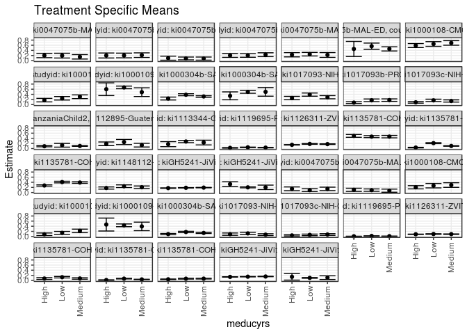

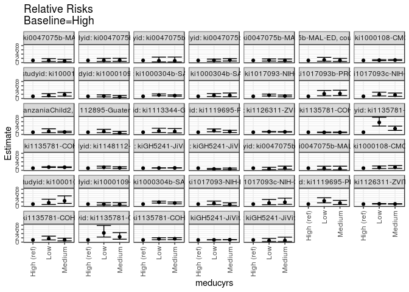

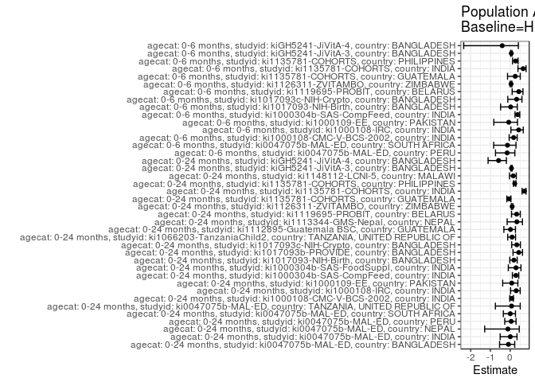

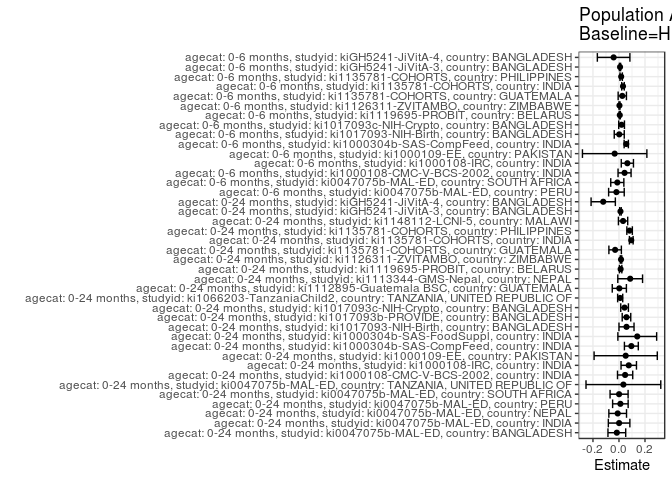

## Results Table

### Parameter: TSM

| agecat | studyid | country | intervention_level | baseline_level | estimate | ci_lower | ci_upper |
| --- | --- | --- | --- | --- | --- | --- | --- |
| 0-24 months | ki0047075b-MAL-ED | BANGLADESH | High | NA | 0.1987531 | 0.1134620 | 0.2840443 |
| 0-24 months | ki0047075b-MAL-ED | BANGLADESH | Low | NA | 0.1938915 | 0.1012406 | 0.2865423 |
| 0-24 months | ki0047075b-MAL-ED | BANGLADESH | Medium | NA | 0.1478755 | 0.0611686 | 0.2345824 |
| 0-24 months | ki0047075b-MAL-ED | INDIA | High | NA | 0.1990357 | 0.1017753 | 0.2962962 |
| 0-24 months | ki0047075b-MAL-ED | INDIA | Low | NA | 0.1999100 | 0.1089860 | 0.2908339 |
| 0-24 months | ki0047075b-MAL-ED | INDIA | Medium | NA | 0.2126527 | 0.1232638 | 0.3020415 |
| 0-24 months | ki0047075b-MAL-ED | NEPAL | High | NA | 0.0943396 | 0.0154705 | 0.1732088 |
| 0-24 months | ki0047075b-MAL-ED | NEPAL | Low | NA | 0.0833333 | 0.0279225 | 0.1387442 |
| 0-24 months | ki0047075b-MAL-ED | NEPAL | Medium | NA | 0.0789474 | 0.0181871 | 0.1397076 |
| 0-24 months | ki0047075b-MAL-ED | PERU | High | NA | 0.2011303 | 0.1261306 | 0.2761300 |
| 0-24 months | ki0047075b-MAL-ED | PERU | Low | NA | 0.2014705 | 0.1310922 | 0.2718488 |
| 0-24 months | ki0047075b-MAL-ED | PERU | Medium | NA | 0.2302897 | 0.1559336 | 0.3046458 |
| 0-24 months | ki0047075b-MAL-ED | SOUTH AFRICA | High | NA | 0.2284498 | 0.1455127 | 0.3113868 |
| 0-24 months | ki0047075b-MAL-ED | SOUTH AFRICA | Low | NA | 0.2501941 | 0.1812971 | 0.3190911 |
| 0-24 months | ki0047075b-MAL-ED | SOUTH AFRICA | Medium | NA | 0.2205108 | 0.1268585 | 0.3141631 |
| 0-24 months | ki0047075b-MAL-ED | TANZANIA, UNITED REPUBLIC OF | High | NA | 0.4545455 | 0.1596129 | 0.7494780 |
| 0-24 months | ki0047075b-MAL-ED | TANZANIA, UNITED REPUBLIC OF | Low | NA | 0.5625000 | 0.4406820 | 0.6843180 |
| 0-24 months | ki0047075b-MAL-ED | TANZANIA, UNITED REPUBLIC OF | Medium | NA | 0.4577465 | 0.3756129 | 0.5398800 |
| 0-24 months | ki1000108-CMC-V-BCS-2002 | INDIA | High | NA | 0.5881959 | 0.5103700 | 0.6660218 |
| 0-24 months | ki1000108-CMC-V-BCS-2002 | INDIA | Low | NA | 0.6494492 | 0.5576040 | 0.7412944 |
| 0-24 months | ki1000108-CMC-V-BCS-2002 | INDIA | Medium | NA | 0.6898115 | 0.6009416 | 0.7786814 |
| 0-24 months | ki1000108-IRC | INDIA | High | NA | 0.1735848 | 0.1048170 | 0.2423526 |
| 0-24 months | ki1000108-IRC | INDIA | Low | NA | 0.2458947 | 0.1780938 | 0.3136957 |
| 0-24 months | ki1000108-IRC | INDIA | Medium | NA | 0.3056128 | 0.2327758 | 0.3784498 |
| 0-24 months | ki1000109-EE | PAKISTAN | High | NA | 0.6000000 | 0.3517516 | 0.8482484 |
| 0-24 months | ki1000109-EE | PAKISTAN | Low | NA | 0.6707317 | 0.6198058 | 0.7216576 |
| 0-24 months | ki1000109-EE | PAKISTAN | Medium | NA | 0.4848485 | 0.3141067 | 0.6555903 |
| 0-24 months | ki1000304b-SAS-CompFeed | INDIA | High | NA | 0.2355464 | 0.1784060 | 0.2926868 |
| 0-24 months | ki1000304b-SAS-CompFeed | INDIA | Low | NA | 0.3847707 | 0.3457926 | 0.4237489 |
| 0-24 months | ki1000304b-SAS-CompFeed | INDIA | Medium | NA | 0.3166458 | 0.2866743 | 0.3466172 |

[output cut: 90 more lines]

### Parameter: E(Y)

| agecat | studyid | country | intervention_level | baseline_level | estimate | ci_lower | ci_upper |
| --- | --- | --- | --- | --- | --- | --- | --- |
| 0-24 months | ki0047075b-MAL-ED | BANGLADESH | NA | NA | 0.1822430 | 0.1303993 | 0.2340867 |
| 0-24 months | ki0047075b-MAL-ED | INDIA | NA | NA | 0.2000000 | 0.1470232 | 0.2529768 |
| 0-24 months | ki0047075b-MAL-ED | NEPAL | NA | NA | 0.0844444 | 0.0480318 | 0.1208571 |
| 0-24 months | ki0047075b-MAL-ED | PERU | NA | NA | 0.2119205 | 0.1657530 | 0.2580880 |
| 0-24 months | ki0047075b-MAL-ED | SOUTH AFRICA | NA | NA | 0.2292994 | 0.1827279 | 0.2758709 |
| 0-24 months | ki0047075b-MAL-ED | TANZANIA, UNITED REPUBLIC OF | NA | NA | 0.4884793 | 0.4218176 | 0.5551409 |
| 0-24 months | ki1000108-CMC-V-BCS-2002 | INDIA | NA | NA | 0.6353887 | 0.5864772 | 0.6843003 |
| 0-24 months | ki1000108-IRC | INDIA | NA | NA | 0.2487805 | 0.2068840 | 0.2906770 |
| 0-24 months | ki1000109-EE | PAKISTAN | NA | NA | 0.6515957 | 0.6033717 | 0.6998198 |
| 0-24 months | ki1000304b-SAS-CompFeed | INDIA | NA | NA | 0.3307241 | 0.3024794 | 0.3589688 |
| 0-24 months | ki1000304b-SAS-FoodSuppl | INDIA | NA | NA | 0.4808612 | 0.4329065 | 0.5288160 |
| 0-24 months | ki1017093-NIH-Birth | BANGLADESH | NA | NA | 0.3116057 | 0.2753823 | 0.3478292 |
| 0-24 months | ki1017093b-PROVIDE | BANGLADESH | NA | NA | 0.1342857 | 0.1090095 | 0.1595619 |
| 0-24 months | ki1017093c-NIH-Crypto | BANGLADESH | NA | NA | 0.1306069 | 0.1066024 | 0.1546113 |
| 0-24 months | ki1066203-TanzaniaChild2 | TANZANIA, UNITED REPUBLIC OF | NA | NA | 0.0993294 | 0.0873254 | 0.1113334 |
| 0-24 months | ki1112895-Guatemala BSC | GUATEMALA | NA | NA | 0.1879433 | 0.1422658 | 0.2336207 |
| 0-24 months | ki1113344-GMS-Nepal | NEPAL | NA | NA | 0.2570952 | 0.2220675 | 0.2921228 |
| 0-24 months | ki1119695-PROBIT | BELARUS | NA | NA | 0.0394153 | 0.0310085 | 0.0478221 |
| 0-24 months | ki1126311-ZVITAMBO | ZIMBABWE | NA | NA | 0.1611755 | 0.1550961 | 0.1672550 |
| 0-24 months | ki1135781-COHORTS | GUATEMALA | NA | NA | 0.4638330 | 0.4371320 | 0.4905339 |
| 0-24 months | ki1135781-COHORTS | INDIA | NA | NA | 0.1320916 | 0.1234158 | 0.1407674 |
| 0-24 months | ki1135781-COHORTS | PHILIPPINES | NA | NA | 0.3561151 | 0.3391405 | 0.3730897 |
| 0-24 months | ki1148112-LCNI-5 | MALAWI | NA | NA | 0.2076167 | 0.1797361 | 0.2354973 |
| 0-24 months | kiGH5241-JiVitA-3 | BANGLADESH | NA | NA | 0.1838835 | 0.1783043 | 0.1894627 |
| 0-24 months | kiGH5241-JiVitA-4 | BANGLADESH | NA | NA | 0.2054616 | 0.1868701 | 0.2240531 |
| 0-6 months | ki0047075b-MAL-ED | PERU | NA | NA | 0.1258278 | 0.0883606 | 0.1632951 |
| 0-6 months | ki0047075b-MAL-ED | SOUTH AFRICA | NA | NA | 0.0923567 | 0.0602816 | 0.1244318 |
| 0-6 months | ki1000108-CMC-V-BCS-2002 | INDIA | NA | NA | 0.2472826 | 0.2031431 | 0.2914222 |
| 0-6 months | ki1000108-IRC | INDIA | NA | NA | 0.1512195 | 0.1164988 | 0.1859402 |
| 0-6 months | ki1000109-EE | PAKISTAN | NA | NA | 0.4335106 | 0.3833540 | 0.4836673 |
| 0-6 months | ki1000304b-SAS-CompFeed | INDIA | NA | NA | 0.1496732 | 0.1307571 | 0.1685893 |
| 0-6 months | ki1017093-NIH-Birth | BANGLADESH | NA | NA | 0.0937997 | 0.0709973 | 0.1166021 |
| 0-6 months | ki1017093c-NIH-Crypto | BANGLADESH | NA | NA | 0.0620053 | 0.0448256 | 0.0791849 |
| 0-6 months | ki1119695-PROBIT | BELARUS | NA | NA | 0.0142071 | 0.0107237 | 0.0176904 |
| 0-6 months | ki1126311-ZVITAMBO | ZIMBABWE | NA | NA | 0.0910128 | 0.0862534 | 0.0957721 |
| 0-6 months | ki1135781-COHORTS | GUATEMALA | NA | NA | 0.1011132 | 0.0831080 | 0.1191183 |
| 0-6 months | ki1135781-COHORTS | INDIA | NA | NA | 0.0473331 | 0.0418015 | 0.0528647 |
| 0-6 months | ki1135781-COHORTS | PHILIPPINES | NA | NA | 0.0624591 | 0.0538810 | 0.0710373 |
| 0-6 months | kiGH5241-JiVitA-3 | BANGLADESH | NA | NA | 0.1467792 | 0.1417628 | 0.1517956 |
| 0-6 months | kiGH5241-JiVitA-4 | BANGLADESH | NA | NA | 0.1017027 | 0.0872868 | 0.1161186 |

### Parameter: RR

| agecat | studyid | country | intervention_level | baseline_level | estimate | ci_lower | ci_upper |
| --- | --- | --- | --- | --- | --- | --- | --- |
| 0-24 months | ki0047075b-MAL-ED | BANGLADESH | High | High | 1.0000000 | 1.0000000 | 1.0000000 |
| 0-24 months | ki0047075b-MAL-ED | BANGLADESH | Low | High | 0.9755393 | 0.5200772 | 1.8298765 |
| 0-24 months | ki0047075b-MAL-ED | BANGLADESH | Medium | High | 0.7440161 | 0.3621003 | 1.5287474 |
| 0-24 months | ki0047075b-MAL-ED | INDIA | High | High | 1.0000000 | 1.0000000 | 1.0000000 |
| 0-24 months | ki0047075b-MAL-ED | INDIA | Low | High | 1.0043923 | 0.5147984 | 1.9596093 |
| 0-24 months | ki0047075b-MAL-ED | INDIA | Medium | High | 1.0684145 | 0.5612114 | 2.0340100 |
| 0-24 months | ki0047075b-MAL-ED | NEPAL | High | High | 1.0000000 | 1.0000000 | 1.0000000 |
| 0-24 months | ki0047075b-MAL-ED | NEPAL | Low | High | 0.8833333 | 0.3035369 | 2.5706190 |
| 0-24 months | ki0047075b-MAL-ED | NEPAL | Medium | High | 0.8368421 | 0.2686218 | 2.6070284 |
| 0-24 months | ki0047075b-MAL-ED | PERU | High | High | 1.0000000 | 1.0000000 | 1.0000000 |
| 0-24 months | ki0047075b-MAL-ED | PERU | Low | High | 1.0016914 | 0.6211887 | 1.6152668 |
| 0-24 months | ki0047075b-MAL-ED | PERU | Medium | High | 1.1449773 | 0.7181399 | 1.8255121 |
| 0-24 months | ki0047075b-MAL-ED | SOUTH AFRICA | High | High | 1.0000000 | 1.0000000 | 1.0000000 |
| 0-24 months | ki0047075b-MAL-ED | SOUTH AFRICA | Low | High | 1.0951822 | 0.6973701 | 1.7199246 |
| 0-24 months | ki0047075b-MAL-ED | SOUTH AFRICA | Medium | High | 0.9652486 | 0.5567724 | 1.6734035 |
| 0-24 months | ki0047075b-MAL-ED | TANZANIA, UNITED REPUBLIC OF | High | High | 1.0000000 | 1.0000000 | 1.0000000 |
| 0-24 months | ki0047075b-MAL-ED | TANZANIA, UNITED REPUBLIC OF | Low | High | 1.2375000 | 0.6244116 | 2.4525588 |
| 0-24 months | ki0047075b-MAL-ED | TANZANIA, UNITED REPUBLIC OF | Medium | High | 1.0070423 | 0.5136638 | 1.9743151 |
| 0-24 months | ki1000108-CMC-V-BCS-2002 | INDIA | High | High | 1.0000000 | 1.0000000 | 1.0000000 |
| 0-24 months | ki1000108-CMC-V-BCS-2002 | INDIA | Low | High | 1.1041376 | 0.9096080 | 1.3402695 |
| 0-24 months | ki1000108-CMC-V-BCS-2002 | INDIA | Medium | High | 1.1727581 | 0.9749470 | 1.4107039 |
| 0-24 months | ki1000108-IRC | INDIA | High | High | 1.0000000 | 1.0000000 | 1.0000000 |
| 0-24 months | ki1000108-IRC | INDIA | Low | High | 1.4165686 | 0.8780999 | 2.2852371 |
| 0-24 months | ki1000108-IRC | INDIA | Medium | High | 1.7605967 | 1.1156017 | 2.7785013 |
| 0-24 months | ki1000109-EE | PAKISTAN | High | High | 1.0000000 | 1.0000000 | 1.0000000 |
| 0-24 months | ki1000109-EE | PAKISTAN | Low | High | 1.1178862 | 0.7340218 | 1.7024964 |
| 0-24 months | ki1000109-EE | PAKISTAN | Medium | High | 0.8080808 | 0.4693454 | 1.3912879 |
| 0-24 months | ki1000304b-SAS-CompFeed | INDIA | High | High | 1.0000000 | 1.0000000 | 1.0000000 |
| 0-24 months | ki1000304b-SAS-CompFeed | INDIA | Low | High | 1.6335243 | 1.2499324 | 2.1348368 |
| 0-24 months | ki1000304b-SAS-CompFeed | INDIA | Medium | High | 1.3443033 | 1.0655016 | 1.6960568 |

[output cut: 90 more lines]

### Parameter: PAR

| agecat | studyid | country | intervention_level | baseline_level | estimate | ci_lower | ci_upper |
| --- | --- | --- | --- | --- | --- | --- | --- |
| 0-24 months | ki0047075b-MAL-ED | BANGLADESH | High | NA | -0.0165101 | -0.0847165 | 0.0516962 |
| 0-24 months | ki0047075b-MAL-ED | INDIA | High | NA | 0.0009643 | -0.0818043 | 0.0837328 |
| 0-24 months | ki0047075b-MAL-ED | NEPAL | High | NA | -0.0098952 | -0.0778345 | 0.0580441 |
| 0-24 months | ki0047075b-MAL-ED | PERU | High | NA | 0.0107902 | -0.0488902 | 0.0704706 |
| 0-24 months | ki0047075b-MAL-ED | SOUTH AFRICA | High | NA | 0.0008496 | -0.0684595 | 0.0701587 |
| 0-24 months | ki0047075b-MAL-ED | TANZANIA, UNITED REPUBLIC OF | High | NA | 0.0339338 | -0.2534861 | 0.3213537 |
| 0-24 months | ki1000108-CMC-V-BCS-2002 | INDIA | High | NA | 0.0471928 | -0.0113264 | 0.1057120 |
| 0-24 months | ki1000108-IRC | INDIA | High | NA | 0.0751957 | 0.0159032 | 0.1344883 |
| 0-24 months | ki1000109-EE | PAKISTAN | High | NA | 0.0515957 | -0.1913770 | 0.2945684 |
| 0-24 months | ki1000304b-SAS-CompFeed | INDIA | High | NA | 0.0951777 | 0.0418378 | 0.1485176 |
| 0-24 months | ki1000304b-SAS-FoodSuppl | INDIA | High | NA | 0.1405546 | -0.0085021 | 0.2896113 |
| 0-24 months | ki1017093-NIH-Birth | BANGLADESH | High | NA | 0.0578623 | 0.0000426 | 0.1156820 |
| 0-24 months | ki1017093b-PROVIDE | BANGLADESH | High | NA | 0.0576305 | 0.0248018 | 0.0904591 |
| 0-24 months | ki1017093c-NIH-Crypto | BANGLADESH | High | NA | 0.0430388 | 0.0135932 | 0.0724844 |
| 0-24 months | ki1066203-TanzaniaChild2 | TANZANIA, UNITED REPUBLIC OF | High | NA | 0.0092369 | -0.0103393 | 0.0288131 |
| 0-24 months | ki1112895-Guatemala BSC | GUATEMALA | High | NA | 0.0026792 | -0.0516850 | 0.0570435 |
| 0-24 months | ki1113344-GMS-Nepal | NEPAL | High | NA | 0.0861364 | -0.0090576 | 0.1813305 |
| 0-24 months | ki1119695-PROBIT | BELARUS | High | NA | 0.0127314 | 0.0035179 | 0.0219449 |
| 0-24 months | ki1126311-ZVITAMBO | ZIMBABWE | High | NA | 0.0157947 | 0.0102634 | 0.0213259 |
| 0-24 months | ki1135781-COHORTS | GUATEMALA | High | NA | -0.0295909 | -0.0775593 | 0.0183776 |
| 0-24 months | ki1135781-COHORTS | INDIA | High | NA | 0.0945183 | 0.0802713 | 0.1087653 |
| 0-24 months | ki1135781-COHORTS | PHILIPPINES | High | NA | 0.0816352 | 0.0604349 | 0.1028355 |
| 0-24 months | ki1148112-LCNI-5 | MALAWI | High | NA | 0.0314247 | -0.0041970 | 0.0670464 |
| 0-24 months | kiGH5241-JiVitA-3 | BANGLADESH | High | NA | 0.0114378 | 0.0057757 | 0.0170998 |
| 0-24 months | kiGH5241-JiVitA-4 | BANGLADESH | High | NA | -0.1211603 | -0.2144420 | -0.0278786 |
| 0-6 months | ki0047075b-MAL-ED | PERU | High | NA | -0.0196212 | -0.0796289 | 0.0403864 |
| 0-6 months | ki0047075b-MAL-ED | SOUTH AFRICA | High | NA | -0.0129065 | -0.0632808 | 0.0374679 |
| 0-6 months | ki1000108-CMC-V-BCS-2002 | INDIA | High | NA | 0.0429059 | -0.0071514 | 0.0929632 |
| 0-6 months | ki1000108-IRC | INDIA | High | NA | 0.0644940 | 0.0176582 | 0.1113299 |
| 0-6 months | ki1000109-EE | PAKISTAN | High | NA | -0.0331560 | -0.2807974 | 0.2144853 |
| 0-6 months | ki1000304b-SAS-CompFeed | INDIA | High | NA | 0.0559666 | 0.0396563 | 0.0722770 |
| 0-6 months | ki1017093-NIH-Birth | BANGLADESH | High | NA | 0.0020870 | -0.0363910 | 0.0405651 |
| 0-6 months | ki1017093c-NIH-Crypto | BANGLADESH | High | NA | 0.0200380 | -0.0020229 | 0.0420989 |
| 0-6 months | ki1119695-PROBIT | BELARUS | High | NA | 0.0061527 | 0.0019494 | 0.0103560 |
| 0-6 months | ki1126311-ZVITAMBO | ZIMBABWE | High | NA | 0.0037083 | -0.0000341 | 0.0074508 |
| 0-6 months | ki1135781-COHORTS | GUATEMALA | High | NA | 0.0254876 | -0.0063923 | 0.0573676 |
| 0-6 months | ki1135781-COHORTS | INDIA | High | NA | 0.0308533 | 0.0209756 | 0.0407310 |
| 0-6 months | ki1135781-COHORTS | PHILIPPINES | High | NA | 0.0169680 | 0.0079165 | 0.0260194 |
| 0-6 months | kiGH5241-JiVitA-3 | BANGLADESH | High | NA | 0.0081071 | 0.0034793 | 0.0127350 |
| 0-6 months | kiGH5241-JiVitA-4 | BANGLADESH | High | NA | -0.0411544 | -0.1662895 | 0.0839806 |

### Parameter: PAF

| agecat | studyid | country | intervention_level | baseline_level | estimate | ci_lower | ci_upper |
| --- | --- | --- | --- | --- | --- | --- | --- |
| 0-24 months | ki0047075b-MAL-ED | BANGLADESH | High | NA | -0.0905939 | -0.5386785 | 0.2270022 |
| 0-24 months | ki0047075b-MAL-ED | INDIA | High | NA | 0.0048213 | -0.5083070 | 0.3433826 |
| 0-24 months | ki0047075b-MAL-ED | NEPAL | High | NA | -0.1171797 | -1.2929418 | 0.4556815 |
| 0-24 months | ki0047075b-MAL-ED | PERU | High | NA | 0.0509163 | -0.2770495 | 0.2946554 |
| 0-24 months | ki0047075b-MAL-ED | SOUTH AFRICA | High | NA | 0.0037052 | -0.3494092 | 0.2644163 |
| 0-24 months | ki0047075b-MAL-ED | TANZANIA, UNITED REPUBLIC OF | High | NA | 0.0694683 | -0.7513527 | 0.5055883 |
| 0-24 months | ki1000108-CMC-V-BCS-2002 | INDIA | High | NA | 0.0742739 | -0.0230230 | 0.1623173 |
| 0-24 months | ki1000108-IRC | INDIA | High | NA | 0.3022573 | 0.0183247 | 0.5040673 |
| 0-24 months | ki1000109-EE | PAKISTAN | High | NA | 0.0791837 | -0.3806881 | 0.3858840 |
| 0-24 months | ki1000304b-SAS-CompFeed | INDIA | High | NA | 0.2877858 | 0.1083037 | 0.4311415 |
| 0-24 months | ki1000304b-SAS-FoodSuppl | INDIA | High | NA | 0.2922976 | -0.0967781 | 0.5433509 |
| 0-24 months | ki1017093-NIH-Birth | BANGLADESH | High | NA | 0.1856908 | -0.0221419 | 0.3512648 |
| 0-24 months | ki1017093b-PROVIDE | BANGLADESH | High | NA | 0.4291630 | 0.1406633 | 0.6208065 |
| 0-24 months | ki1017093c-NIH-Crypto | BANGLADESH | High | NA | 0.3295292 | 0.0751274 | 0.5139535 |
| 0-24 months | ki1066203-TanzaniaChild2 | TANZANIA, UNITED REPUBLIC OF | High | NA | 0.0929924 | -0.1265484 | 0.2697492 |
| 0-24 months | ki1112895-Guatemala BSC | GUATEMALA | High | NA | 0.0142556 | -0.3219600 | 0.2649612 |
| 0-24 months | ki1113344-GMS-Nepal | NEPAL | High | NA | 0.3350372 | -0.1563853 | 0.6176227 |
| 0-24 months | ki1119695-PROBIT | BELARUS | High | NA | 0.3230065 | 0.0664644 | 0.5090490 |
| 0-24 months | ki1126311-ZVITAMBO | ZIMBABWE | High | NA | 0.0979966 | 0.0631818 | 0.1315176 |
| 0-24 months | ki1135781-COHORTS | GUATEMALA | High | NA | -0.0637964 | -0.1725682 | 0.0348853 |
| 0-24 months | ki1135781-COHORTS | INDIA | High | NA | 0.7155512 | 0.5990342 | 0.7982095 |
| 0-24 months | ki1135781-COHORTS | PHILIPPINES | High | NA | 0.2292381 | 0.1676405 | 0.2862773 |
| 0-24 months | ki1148112-LCNI-5 | MALAWI | High | NA | 0.1513592 | -0.0372778 | 0.3056910 |
| 0-24 months | kiGH5241-JiVitA-3 | BANGLADESH | High | NA | 0.0622011 | 0.0309996 | 0.0923978 |
| 0-24 months | kiGH5241-JiVitA-4 | BANGLADESH | High | NA | -0.5896978 | -1.1203478 | -0.1918513 |
| 0-6 months | ki0047075b-MAL-ED | PERU | High | NA | -0.1559369 | -0.7442107 | 0.2339284 |
| 0-6 months | ki0047075b-MAL-ED | SOUTH AFRICA | High | NA | -0.1397459 | -0.8365787 | 0.2926953 |
| 0-6 months | ki1000108-CMC-V-BCS-2002 | INDIA | High | NA | 0.1735096 | -0.0538539 | 0.3518205 |
| 0-6 months | ki1000108-IRC | INDIA | High | NA | 0.4264926 | 0.0352476 | 0.6590724 |
| 0-6 months | ki1000109-EE | PAKISTAN | High | NA | -0.0764826 | -0.8301541 | 0.3668212 |
| 0-6 months | ki1000304b-SAS-CompFeed | INDIA | High | NA | 0.3739256 | 0.2419148 | 0.4829485 |
| 0-6 months | ki1017093-NIH-Birth | BANGLADESH | High | NA | 0.0222499 | -0.4873571 | 0.3572523 |
| 0-6 months | ki1017093c-NIH-Crypto | BANGLADESH | High | NA | 0.3231665 | -0.1230283 | 0.5920818 |
| 0-6 months | ki1119695-PROBIT | BELARUS | High | NA | 0.4330725 | 0.0974387 | 0.6438947 |
| 0-6 months | ki1126311-ZVITAMBO | ZIMBABWE | High | NA | 0.0407451 | -0.0011942 | 0.0809276 |
| 0-6 months | ki1135781-COHORTS | GUATEMALA | High | NA | 0.2520704 | -0.1359520 | 0.5075507 |
| 0-6 months | ki1135781-COHORTS | INDIA | High | NA | 0.6518334 | 0.3909450 | 0.8009704 |
| 0-6 months | ki1135781-COHORTS | PHILIPPINES | High | NA | 0.2716651 | 0.1184231 | 0.3982695 |
| 0-6 months | kiGH5241-JiVitA-3 | BANGLADESH | High | NA | 0.0552335 | 0.0232243 | 0.0861937 |
| 0-6 months | kiGH5241-JiVitA-4 | BANGLADESH | High | NA | -0.4046541 | -2.3525270 | 0.4114728 |